# Deep Dive on Clear By Description - No Police Action Possible or Necessary

Francine Stephens

Last Updated: February 22, 2021

The set of descriptive and spatial analyses in this web-report is a follow up on the [preliminary exploratory analysis](https://francine-stephens.github.io/francinestephens.github.io/cad19_eda.html). We take a deeper dive into the cases that had the clear by description “No police action possible or necessary.” This web-report tackles two questions about this type of resolution, which I will refer to as NPAPN:

1. What types of cases had the NPAPN resolution?
2. Where are the cases with NPAPN resolutions located?

## What types of cases had the clear by description NPAPN?

No police action was deemed possible or necessary for **19,290 calls.** There are **63 different types of cases** that had been deemed NPAPN. The full list of case types and their frequencies can be downloaded as an [Excel file](https://docs.google.com/spreadsheets/d/1hYHU6ADwO-XHV8gMm6WExEk0kjkYDeeuYlKvu3AX6EI/edit?usp=sharing). To keep the number of categories more manageable, I graphed the top 20 case types with this type of resolution below in the Figure 1.

```r
## Reduce to no police action resolutions & export
no_police_action <- cad %>%
  filter(Clear_By_Desc == "NO POLICE ACTION POSSIBLE OR NECESSARY")

no_police_action_case_types <- no_police_action %>%
  group_by(Case_Type_Final_Desc) %>%
  summarize(freq = n()
            ) %>%
  mutate(percent = round((freq/sum(freq)) * 100, digits=2)) %>%
  arrange(-freq)

## Uncomment code below to export if changes are made
# write_csv(no_police_action_case_types,
#           "no_police_action_case_types.csv",
#           na = "")

rm(no_police_action_case_types)
```

**Disturbance, suspicious person, and trespass calls made up 44% of all calls about cases that were deemed NPAPN.**

- Disturbance and suspicious person are the top 2 most common. Disturbance calls make up about 27% of these cases and suspicious person cases are 15%.
- Trespass cases are in the top 20, but rank lower than our other two focal cases at 9th most frequent.
- Traffic related cases and assisting the public were also among the top 5 most common cases.

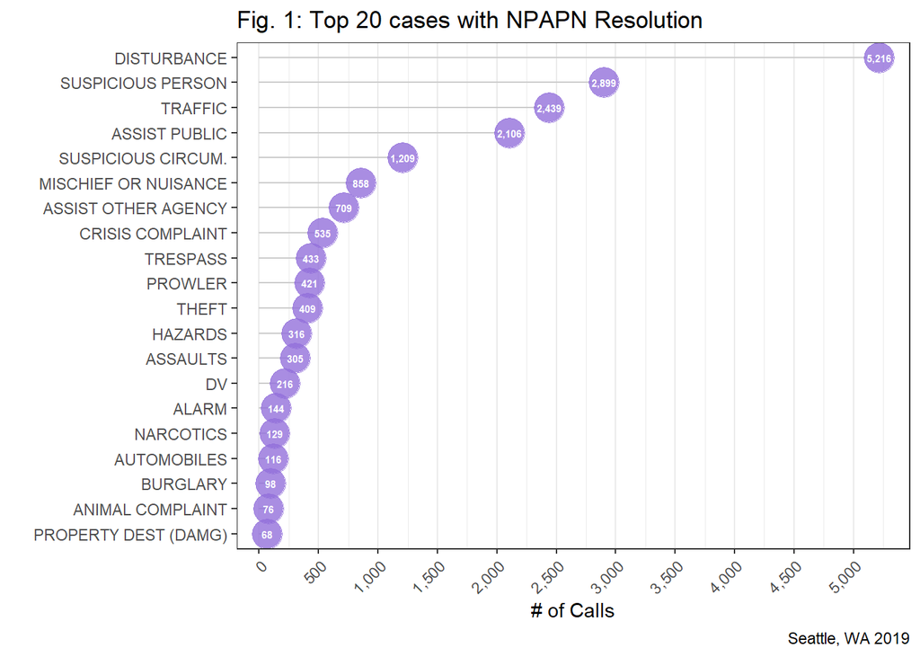

```r
## Aggregate case types for graphing
no_police_action_case_freq <- no_police_action %>%
  mutate(
         Case_Type_Final_Desc = str_replace(
           Case_Type_Final_Desc, c("PROWLER - TRESPASS",
                                   "PROWLER - TRESPASS, PARKS EXCLUSION"), "TRESPASS"),
         Case_Type_Final_Desc = str_replace(
           Case_Type_Final_Desc, "DV - ARGUMENTS, DISTURBANCE (NO ARREST)",
           "DISTURBANCE - DV"),
         Case_Type_Final_Desc = str_replace(Case_Type_Final_Desc,
                                            "NOISE - DIST, GENERAL (CONST, RESID, BALL PLAY)",
                                            "DISTURBANCE - NOISE, GENERAL"),
         Case_Type_Final_Desc = str_replace(Case_Type_Final_Desc,
                                            "NOISE - DISTURBANCE (PARTY, ETC)",
                                            "DISTURBANCE - NOISE, GENERAL"),
         Case_Type_Final_Desc = str_replace(Case_Type_Final_Desc,
                                            "SUSPICIOUS CIRCUM. - SUSPICIOUS PERSON",
                                            "SUSPICIOUS PERSON"),
         Case_Type_Final_Desc = str_replace(Case_Type_Final_Desc,
                                            "ASSAULTS, OTHER",
                                            "ASSAULTS"),
         Case_Type_Final_Desc = str_replace(Case_Type_Final_Desc,
                                            "PERSON - RUNAWAY",
                                            "RUNAWAY PERSON"),
         case_type_final_desc_first = str_trim(str_extract(Case_Type_Final_Desc, "[^-]+")),
         case_type_final_desc_first = recode_factor(case_type_final_desc_first,
                                     "TRESPASS, PARKS EXCLUSION" = "TRESPASS",
                                     "CASUALTY,NON" = "CASUALTY NON CRIMINAL",
                                     "#NAME?" = "UNKNOWN",
                                     "UNKNOWN?" = "UNKNOWN",
                                     "HAZ" = "HAZARDS",
                                     "SEX OFFENSES (NON" = "SEX OFFENSES (NON RAPE)",
                                     "MISSING" = "MISSING PERSON",
                                     "PERSON" = "MISSING PERSON",
                                     "HARAS" = "HARASSMENT",
                                     "DOWN" = "DOWN PERSON",
                                     "BURN" = "RECKLESS BURNING",
                                     "SERVICE" = "WELFARE CHECK",
                                     "WEAPN" = "WEAPON",
                                     "WEAPON,PERSON WITH" = "WEAPON",
                                     "WEAPON, PERSON WITH" = "WEAPON",
                                     "CASUALTY NON" = "CASUALTY DRUG RELATED",
                                     "DISTURBANCE, MISCELLANEOUS/OTHER" = "DISTURBANCE",
                                     "NUISANCE" = "NUISANCE OR MISCHIEF",
                                     "CHILD" = "ABANDONED, ABUSED AND NEGLECTED CHILD"
                                     )) %>%
  group_by(case_type_final_desc_first) %>%
  summarize(n = n()
            ) %>%
  mutate(percent = round((n/sum(n)) * 100, digits=2)) %>%
  arrange(-n)

## Graph of top 20
no_police_action_case_freq %>%
  slice(1:20) %>%
 ggplot(., aes(x = n, y = reorder(case_type_final_desc_first, n), label = comma(n, accuracy=1))) +
  geom_segment(aes(yend = case_type_final_desc_first), xend = 0, colour = "grey80") +
  geom_point(size = 7.5, color = "mediumpurple", alpha=0.8) +
  geom_text(size = 2, color = "white", fontface = "bold") +
  labs(title = "Fig. 1: Top 20 cases with NPAPN Resolution",
       x = "# of Calls",
       y = "",
       caption = "Seattle, WA 2019") +
  scale_x_continuous(labels = scales::comma, breaks=pretty_breaks(n=10)) +
  theme_bw() +
  theme(
  panel.grid.major.y = element_blank(),
  axis.text.x = element_text(angle = 45, hjust=1)
)
```

In addition to knowing the raw frequencies of cases that were deemed NPAPN, knowing the proportion of each type of case resolved in this manner would be informative. Figure 2 shows the breakdown of this type of resolution for the top 20 case types.

**The rankings shift when we consider the share of these top 20 cases deemed NPAPN. Among these case types, no case type had more than 11% of the cases in 2019 that were classified as NPAPN.**

- Of all suspicious circumstances cases in 2019, just over 10% were resolved in this manner.
- The shares for Mischief/Nuisance and Animal Complaint were just under 10%.
- For approximately 6% of disturbance and suspicious persons cases were classified as NPAPN.
- Just over 3% of trespass cases were classified as NPAPN.
- The top 10 case types in the graphic have shares of NPAPN resolved cases that are above the average for all case types that had NPAPN resolutions.

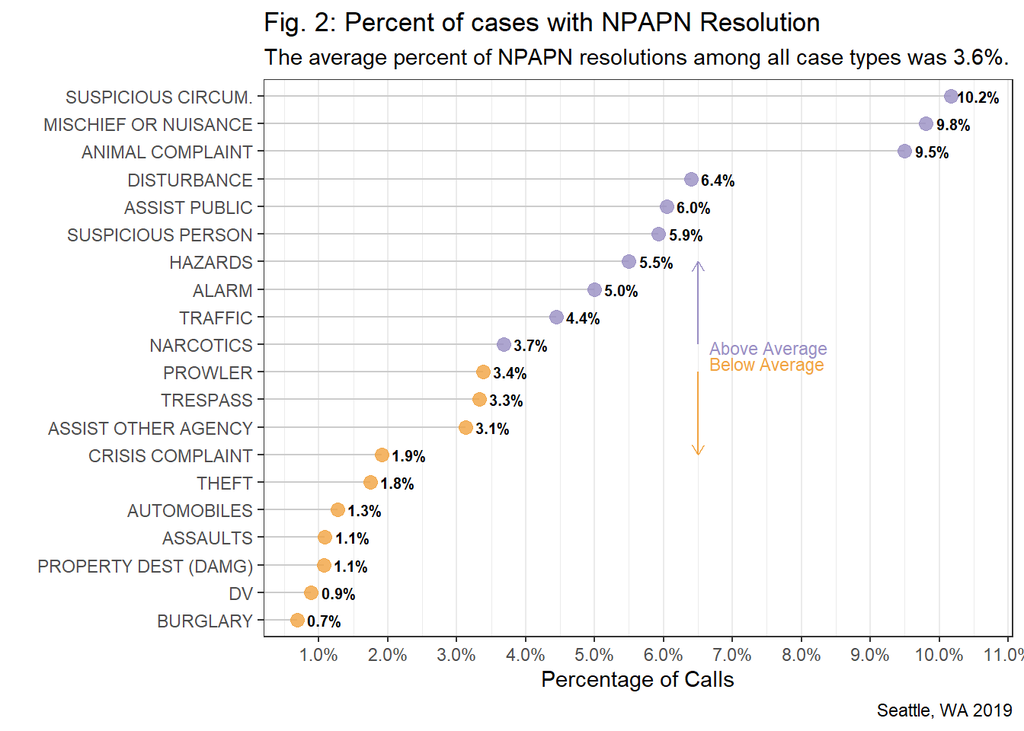

```r
## Create lolliplot of % resolved w/o police action
# Extract top 20 case type names
top_20_case_types_no_pols_action <- no_police_action_case_freq %>%
  slice(1:20) %>%
  select(case_type_final_desc_first)

perc_no_police_action <- cad %>%
  mutate(no_police_action = as.factor(if_else(
    Clear_By_Desc == "NO POLICE ACTION POSSIBLE OR NECESSARY",
                                    1,
                                    0)),
    no_police_action = recode_factor(no_police_action,
                                          "0" = "OTHER RESOLUTION",
                                          "1" = "NO POLICE ACTION POSSIBLE OR NECESSARY"),
    Case_Type_Final_Desc = str_replace(
    Case_Type_Final_Desc, c("PROWLER - TRESPASS",
                                   "PROWLER - TRESPASS, PARKS EXCLUSION"), "TRESPASS"),
    Case_Type_Final_Desc = str_replace(
    Case_Type_Final_Desc, "DV - ARGUMENTS, DISTURBANCE (NO ARREST)",
           "DISTURBANCE - DV"),
    Case_Type_Final_Desc = str_replace(Case_Type_Final_Desc,
                                            "NOISE - DIST, GENERAL (CONST, RESID, BALL PLAY)",
                                            "DISTURBANCE - NOISE, GENERAL"),
    Case_Type_Final_Desc = str_replace(Case_Type_Final_Desc,
                                            "NOISE - DISTURBANCE (PARTY, ETC)",
                                            "DISTURBANCE - NOISE, GENERAL"),
    Case_Type_Final_Desc = str_replace(Case_Type_Final_Desc,
                                            "SUSPICIOUS CIRCUM. - SUSPICIOUS PERSON",
                                            "SUSPICIOUS PERSON"),
    Case_Type_Final_Desc = str_replace(Case_Type_Final_Desc,
                                            "ASSAULTS, OTHER",
                                            "ASSAULTS"),
    Case_Type_Final_Desc = str_replace(Case_Type_Final_Desc,
                                            "PERSON - RUNAWAY",
                                            "RUNAWAY PERSON"),
    case_type_final_desc_first = str_trim(str_extract(Case_Type_Final_Desc, "[^-]+")),
    case_type_final_desc_first = recode_factor(case_type_final_desc_first,
                                     "TRESPASS, PARKS EXCLUSION" = "TRESPASS",
                                     "CASUALTY,NON" = "CASUALTY NON CRIMINAL",
                                     "#NAME?" = "UNKNOWN",
                                     "UNKNOWN?" = "UNKNOWN",
                                     "HAZ" = "HAZARDS",
                                     "SEX OFFENSES (NON" = "SEX OFFENSES (NON RAPE)",
                                     "MISSING" = "MISSING PERSON",
                                     "PERSON" = "MISSING PERSON",
                                     "HARAS" = "HARASSMENT",
                                     "DOWN" = "DOWN PERSON",
                                     "BURN" = "RECKLESS BURNING",
                                     "SERVICE" = "WELFARE CHECK",
                                     "WEAPN" = "WEAPON",
                                     "WEAPON,PERSON WITH" = "WEAPON",
                                     "WEAPON, PERSON WITH" = "WEAPON",
                                     "CASUALTY NON" = "CASUALTY DRUG RELATED",
                                     "DISTURBANCE, MISCELLANEOUS/OTHER" = "DISTURBANCE",
                                     "NUISANCE" = "NUISANCE OR MISCHIEF",
                                     "CHILD" = "ABANDONED, ABUSED AND NEGLECTED CHILD"
                                     )) %>%
  filter(case_type_final_desc_first %in% top_20_case_types_no_pols_action$case_type_final_desc_first) %>%
  count(case_type_final_desc_first, no_police_action) %>%
  group_by(case_type_final_desc_first) %>%
  mutate(percent = round((n/sum(n)) * 100, digits=2),
         above_average_pct = as.factor(if_else(percent > 3.65,
                                               1,
                                               0))) %>%
  filter(no_police_action != "OTHER RESOLUTION")

## Get summary stats of % NPAPN
# pct_no_pols_action <- cad %>%
#   mutate(no_police_action = as.factor(if_else(
#     Clear_By_Desc == "NO POLICE ACTION POSSIBLE OR NECESSARY",
#                                     1,
#                                     0)),
#     no_police_action = recode_factor(no_police_action,
#                                           "0" = "OTHER RESOLUTION",
#                                           "1" = "NO POLICE ACTION POSSIBLE OR NECESSARY"),
#     Case_Type_Final_Desc = str_replace(
#     Case_Type_Final_Desc, c("PROWLER - TRESPASS",
#                                    "PROWLER - TRESPASS, PARKS EXCLUSION"), "TRESPASS"),
#     Case_Type_Final_Desc = str_replace(
#     Case_Type_Final_Desc, "DV - ARGUMENTS, DISTURBANCE (NO ARREST)",
#            "DISTURBANCE - DV"),
#     Case_Type_Final_Desc = str_replace(Case_Type_Final_Desc,
#                                             "NOISE - DIST, GENERAL (CONST, RESID, BALL PLAY)",
#                                             "DISTURBANCE - NOISE, GENERAL"),
#     Case_Type_Final_Desc = str_replace(Case_Type_Final_Desc,
#                                             "NOISE - DISTURBANCE (PARTY, ETC)",
#                                             "DISTURBANCE - NOISE, GENERAL"),
#     Case_Type_Final_Desc = str_replace(Case_Type_Final_Desc,
#                                             "SUSPICIOUS CIRCUM. - SUSPICIOUS PERSON",
#                                             "SUSPICIOUS PERSON"),
#     Case_Type_Final_Desc = str_replace(Case_Type_Final_Desc,
#                                             "ASSAULTS, OTHER",
#                                             "ASSAULTS"),
#     Case_Type_Final_Desc = str_replace(Case_Type_Final_Desc,
#                                             "PERSON - RUNAWAY",
#                                             "RUNAWAY PERSON"),
#     case_type_final_desc_first = str_trim(str_extract(Case_Type_Final_Desc, "[^-]+")),
#     case_type_final_desc_first = recode_factor(case_type_final_desc_first,
#                                      "TRESPASS, PARKS EXCLUSION" = "TRESPASS",
#                                      "CASUALTY,NON" = "CASUALTY NON CRIMINAL",
#                                      "#NAME?" = "UNKNOWN",
#                                      "UNKNOWN?" = "UNKNOWN",
#                                      "HAZ" = "HAZARDS",
#                                      "SEX OFFENSES (NON" = "SEX OFFENSES (NON RAPE)",
#                                      "MISSING" = "MISSING PERSON",
#                                      "PERSON" = "MISSING PERSON",
#                                      "HARAS" = "HARASSMENT",
#                                      "DOWN" = "DOWN PERSON",
#                                      "BURN" = "RECKLESS BURNING",
#                                      "SERVICE" = "WELFARE CHECK",
#                                      "WEAPN" = "WEAPON",
#                                      "WEAPON,PERSON WITH" = "WEAPON",
#                                      "WEAPON, PERSON WITH" = "WEAPON",
#                                      "CASUALTY NON" = "CASUALTY DRUG RELATED",
#                                      "DISTURBANCE, MISCELLANEOUS/OTHER" = "DISTURBANCE",
#                                      "NUISANCE" = "NUISANCE OR MISCHIEF",
#                                      "CHILD" = "ABANDONED, ABUSED AND NEGLECTED CHILD"
#                                      )) %>%
#   count(case_type_final_desc_first, no_police_action) %>%
#   group_by(case_type_final_desc_first) %>%
#   mutate(percent = round((n/sum(n)) * 100, digits=2)) %>%
#   filter(no_police_action != "OTHER RESOLUTION") %>%
#   select(-no_police_action) %>%
#   ungroup() %>%
#   summarize(avg_pct_no_pols_action = mean(percent, na.rm = T),
#             sd_pct_no_pols_action = sd(percent, na.rm = T),
#             med_pct_no_pols_action = median(percent),
#             max_pct_no_pols_action = max(percent)
#             )

## GRAPHIC
ggplot(perc_no_police_action,
       aes(x = percent,
           y = reorder(case_type_final_desc_first, percent),
           label = percent(percent, accuracy = 0.1, scale = 1, suffix = "%"))) +
  geom_segment(aes(yend = case_type_final_desc_first), xend = 0, colour = "grey80") +
  geom_point(size = 3, aes(color=factor(above_average_pct)), alpha=0.8) +
  geom_text(size = 2.7, fontface = "bold", nudge_x = 0.4) +
  annotate("text", x = 6.5, y = "NARCOTICS", label = "Above Average",
           color = "#998ec3", size = 3, hjust = -0.1, vjust = .75) +
  annotate("text", x = 6.5, y = "PROWLER", label = "Below Average",
           color = "#f1a340", size = 3, hjust = -0.1, vjust = -.1) +
  geom_segment(aes(x = 6.5, xend = 6.5 , y = "NARCOTICS", yend = "HAZARDS"),
                     arrow = arrow(length = unit(0.2,"cm")), color = "#998ec3") +
  geom_segment(aes(x = 6.5, xend = 6.5 , y = "PROWLER", yend = "CRISIS COMPLAINT"),
                     arrow = arrow(length = unit(0.2,"cm")), color = "#f1a340") +
  labs(title = "Fig. 2: Percent of cases with NPAPN Resolution",
       x = "Percentage of Calls",
       y = "",
       subtitle = "The average percent of NPAPN resolutions among all case types was 3.6%.",
       caption = "Seattle, WA 2019") +
  scale_x_continuous(labels = scales::percent_format(accuracy = 0.1, scale = 1, suffix = "%"),
                     breaks=pretty_breaks(n = 10)) +
  scale_color_manual(values=c("#f1a340", "#998ec3")) +
  theme_bw() +
  theme(
  legend.position = "none",
  panel.grid.major.y = element_blank(),
  axis.text.x = element_text(angle = 0)
)
```

#### CONSIDERATIONS FOR FUTURE ANALYSIS

- **Suspicious circumstances** - Any interest in tracking this case type, too? There may be fewer calls from this case than suspicious person, but it seems like a greater share of the suspicious circumstances are resolved in this way. Perhaps run comparisons between suspicious persons and circumstances spatially too.
- **Prowler** - Trespass and prowler also tend to mirror each other in tabulations. Tracking these two spatially may be useful.

## Where are the cases that were resolved by NPAPN located?

18,8447 calls about cases that had been resolved by NPAPN had valid geographic coordinates for mapping. These point locations have been mapped and aggregated to the Seattle Police Department’s geographic units as well as a density raster grid constructed using 1/8th of a square mile areal units.

### By Precinct

The precinct-level map shows that the cases resolved by NPAPN are largely in the north and west precincts. East and south precincts are in the middle of the distribution with about half the number of cases resolved by NPAPN compared to the north and west. The southwestern precinct has the fewest hovering around 2,000.

*NOTE: NA precinct includes the harbor and northern and southern periphery of Seattle. Seattle Police Department does not explain why these areas (in particular the northern and southern areas) do not get assigned to a precinct, but get assigned to sectors and beats.*

[interactive chart not shown]

### By Sector

*West Precinct*

- Sector K lead all sectors in the number of calls resolved by NPAPN with 1,990 calls.
  - Sector K is located in the southwestern edge of the west precinct and borders the south and southwest precincts.
- Just to northwest of Sector K, Sector M had about half the number of calls resolved by NPAPN.
- All of the other sectors in the west precinct had just over 1,000 calls cleared by NPAPN.

*North Precinct*

- Sector B in the north precinct had the next highest count of calls cleared by NPAPN at 1,884.
  - Like the west precinct’s sectors, the other northern precinct sectors had around 1,000 calls cleared by NPAPN.
- Sector U had the fewest, which is where the University of Washington’s campus is located.

*East, South, and Southwest Precincts*

- The leading sector in the southern precinct is sector R with 1,135 calls cleared in this manner.
- The leading sector in the southwestern precinct is sector W, which had 1,138 calls.
- The leading sector in the eastern precinct was sector E with 1,074 calls cleared by NPAPN.

[interactive chart not shown]

### By Beat

*West Precinct*

- Half of the NPAPN resolved calls in sector K occurred in Beat K3. Beat K3 had the highest number of NPAPN resolutions with 1,000. This beat includes the International District/Chinatown.
- The next highest beat was also in sector K - K2 with 581 calls resolved by NPAPN. K2 is located just to the west of K1.

*North Precinct*

- The beats along the southwestern end of the northern precinct, just to the north of the Washington Ship Canal, had the most calls resolved by NPAPN. B2 had 659, B3 had 649, and B1 had 576. These beats are to the west of University of Washington. They include Woodland Park and Zoo.

*Southwest Precinct*

- Beats on the northwestern part of the southwestern precinct that are closest to the western portion of the harbor had the highest number of NPAPN resolved calls. W2 had 430 and W1 had 391.

*South Precinct*

- Beat R2 stood out as the top beat for NPAPN in the south precinct with 492 calls. This beat encompasses the Mount Baker (neighborhood/area?).

*East Precinct*

- The E1 beat had 437 calls resolved by NPAPN - the highest number in the eastern precinct. This beat includes Capitol Hill.
- The other beats in the eastern precinct had considerably fewer NPAPN resolutions.

[interactive chart not shown]

### Hot Spots

The interactive map below shows the NPAPN hot and cold spots. A raster grid was computed by dividing the city into one-eighth square mile regions and then aggregating the number of NPAPN resolutions within each region. The number of points per region was compared to the average of the region’s contiguous neighbor regions. Each region was compared to a neighborhood of contiguous regions. If a region’s number of NPAPN calls were significantly higher than the average NPAPN resolutions in its neighborhood, then the region is considered a hot spot. If a region’s number of NPAPN calls was significantly lower than the average NPAPN resolutions in its neighborhood, then the region is considered a cold spot.

Pan and zoom in to the different beats to see where the “hot spots” are located (e.g., bounded by highways, near parks, transit stations, etc.)

*West Precinct*

- Most of sectors K and M, which are in the downtown area are classified as hot spots.
- Lower Queen Anne neighborhood in beat Q3 near Key Arena has a sizeable patch of hot spots.
- The southern portion of Beat D3, near the beats in sectors K and M, also has some significant hot spots.

*North Precinct*

- Hot spots in the north are scattered compared to those in the west which are localized in the core of the city.
- Parts of the University of Washington Campus in Beat U2 have hot spots.
- Beat B1 around the Ballard area has a patch of hot spots.
- In the far northern part of the precinct in Beat L3 around Lake City there is a prominent hot spot area.
- This precinct is the only one to contain cold spots. They are in beats B2, B3, U1, and U3

*Southwest Precinct*

- Hot spots are in the two beats with the highest number of NPAPN resolutions in the precinct - W2 and W1.
- W2 hot spots are around California Avenue between Oregon St and SW Edmunds St.
- W1 hot spots are in the Delridge neighborhood. There are hot spots the around the Puget Creek Green Space and near Cottage Grove Park.

*South Precinct*

- Beat R2, which had the highest number of NPAPN resolutions in the south precinct, also had a patch of hot spots around York’s Playground and Rainier Square Plaza.

*East Precinct*

- The hot spots in the east precinct are adjacent to hot spots in the west precinct. They tend to be located near the Capitol Hill neighborhood (Sector E).

```r
## CALCULATE Getis- Ord GI statistic
# Create a regular grid of 1/8-mile-square crime areas via a raster
pixelsize = 660
box = round(extent(seattle_sp) / pixelsize) * pixelsize
template = raster(box, crs = proj,
    nrows = (box@ymax - box@ymin) / pixelsize,
    ncols = (box@xmax - box@xmin) / pixelsize)

no_police_action_pts_sp$PRESENT = 1
getisraster = rasterize(no_police_action_pts_sp,
                        template,
                        field = 'PRESENT',
                        fun = sum)
getisgrid = rasterToPolygons(getisraster)

# Create list of neighbors
neighbors = poly2nb(getisgrid)
weighted_neighbors = nb2listw(neighbors,
                              zero.policy = T)

# Perform local G analysis (Getis-Ord GI*)
getisgrid$HOTSPOT = as.vector(localG(getisgrid$layer, weighted_neighbors))

## UNCOMMENT TO COLOR GRID CELLS BASED ON Z SCORE & VIEW PLOT
breaks = c(-30, -1.96, -1, 1, 1.96, 30)
    # palette=c("#0000FF80", "#8080FF80", "#FFFFFF80", "#FF808080", "#FF000080")
    # col = palette[cut(getisgrid$HOTSPOT, breaks)]

    # plot(getisgrid, col=col, border=NA)
    # plot(seattle_sp, border="gray", add=T)
```

```r
## VISUALIZE LOCAL G - HOT SPOT MAP
getisgrid <- spTransform(getisgrid, CRS("+init=epsg:4326"))
no_pol_action_getis_pal <-
  colorBin(palette = c("#0000FF80",
                       "#8080FF80",
                       "#FFFFFF80",
                       "#FF808080",
                       "#FF000080"),
           bins=breaks,
           na.color = "#808080")

leaflet() %>%
  addMapboxTiles(
    style_id = "dark-v9",
    username = "mapbox"
  ) %>%
  addPolygons(data = beats_sf,
              fill = F,
              color = "white",
              weight = 1,
              label = ~paste0("Beat ", beat)
    ) %>%
  addPolygons(data = getisgrid,
              color = ~no_pol_action_getis_pal(HOTSPOT),
              stroke = F,
              fillOpacity = 0.5,
              smoothFactor = 0.5,
  ) %>%
  addLegend(data = getisgrid,
  colors = c("#0000FF80", "#8080FF80", "#FFFFFF80", "#FF808080", "#FF000080", "#808080"),
  labels = c("Cold Spot > 2 Std. Dev.",
             "Cold Spot 1 - 2 Std. Dev.",
             "Not Significant",
             "Hot Spot  1 - 2 Std. Dev.",
             "Hot Spot > 2 Std. Dev.",
             "NA"),
  title = "Getis-Ord GI* Hot-Spots<br>of NPAPN Resolutions") %>%
  setView(lng = -122.3321, lat = 47.6062, zoom = 11)
```

[interactive chart not shown]

## Takeaways & Lingering Questions

**Top Lines**

- Disturbance cases made up most of the NPAPN resolutions.
- Suspicious person cases are also a common case type with NPAPN resolutions.
- However, NPAPN resolutions made up only 6% of the resolutions for disturbance and suspicious persons cases.
- Of the top 20 case types, about one-tenth of suspicious circumstances and mischief or nuisance cases in 2019 were resolved by NPAPN.
- Most NPAPN resolutions were in the northern precinct, followed by the western precinct. The three beats in Sector B in the north precincts were were most of the NPAPN resolutions occurred. In the western precinct, the two beats in Sector K at the southwestern edge of the precinct - K2 and K3 - are driving the high number of NPAPN resolutions.
- The highest intensity of resolutions are in the western precinct in the beats/areas that make up of the downtown/city’s core.
- There are hot spots in other precincts, but they don’t really follow a pattern of being centrally or peripherally located.

**Questions for next steps**

- What is the interest motivating the “where” questions? Proximity to certain features? Density/Concentration? Distribution? Relationships between demographics and events?
  - This should inform what types of units to use - census geography, rasters of different sizes.
- Is there an interest in comparing the different cases resolved by NPAPN?
  - I did a quick multi-type point analysis, and the top 20 case types resolved by NPAPN listed above tend to be collocated. There was not any evidence of two case types being resolved this way tending to occur in different locations.
  - Or, is there an interest in whether NPAPN co-occurs with other types of resolutions or is unique?
- It is possible to drill down a little more and focus on particular beats or sectors and compute additional local spatial statistics.